# Lab 5 TEAM: ALL STARS

Johnny Tamanaha, Emily Archambault, Eugene Miller, Kaiyuan Fan, Jingzhi Zhang

9/29/2019

### Plot For States We Have Lived In

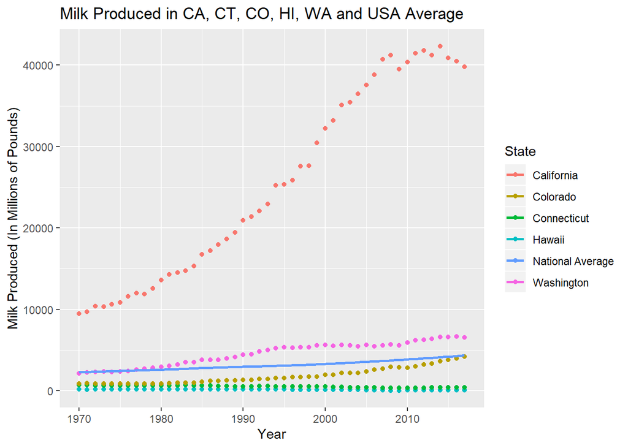

Findings: This plot shows that California milk production slowed down after 2007 while nationally milk production continued to increase. The milk production in Hawaii has always been far below the U.S. average, the milk production in Hawaii has had a small decrease over time. Connecticut has similar trends to Hawaii. Both Colorado and Washington show slight upward trends that hold for recent years.

### Jingzhi Zhang 1998

Plot of milk produced for year 1998

```
##             region          state year milk_produced milk_million
## 1        Northeast          Maine 1998    6.8000e+08          680
## 2        Northeast  New Hampshire 1998    3.3300e+08          333
## 3        Northeast        Vermont 1998    2.6500e+09         2650
## 4        Northeast  Massachusetts 1998    4.3800e+08          438
## 5        Northeast   Rhode Island 1998    3.3000e+07           33
## 6        Northeast    Connecticut 1998    5.2900e+08          529
## 7        Northeast       New York 1998    1.1750e+10        11750
## 8        Northeast     New Jersey 1998    2.9200e+08          292
## 9        Northeast   Pennsylvania 1998    1.0847e+10        10847
## 10       Northeast       Delaware 1998    1.5900e+08          159
## 11       Northeast       Maryland 1998    1.3400e+09         1340
## 12     Lake States       Michigan 1998    5.3650e+09         5365
## 13     Lake States      Wisconsin 1998    2.2842e+10        22842
## 14     Lake States      Minnesota 1998    9.2750e+09         9275
```

[output cut: 36 more lines]

[figure not shown]

Summary of milk produced by state in 1998:

```
## # A tibble: 50 x 2
##    state       Sum1998
##    <fct>         <dbl>
##  1 Alabama         386
##  2 Alaska           14
##  3 Arizona        2680
##  4 Arkansas        540
##  5 California    27620
##  6 Colorado       1689
##  7 Connecticut     529
##  8 Delaware        159
##  9 Florida        2337
## 10 Georgia        1437
## # ... with 40 more rows
```

```
##   Ave1998
## 1 3145.22
```

Average milk produced by each state in 1998 = 3145.22 million lb.

```
##   Median1998
## 1     1411.5
```

The median milk produced be each state in 1998 = 1411.5 million lb.

```
##    region      state year milk_produced milk_million
## 1 Pacific California 1998     2.762e+10        27620
```

The state that produced the most milk in 1998 is California.

```
##    region  state year milk_produced milk_million
## 1 Pacific Alaska 1998       1.4e+07           14
```

The state that produced the least milk in 1998 is Alaska.

### Kaiyuan Fan 1998

Plot of milk produced for year 1998:

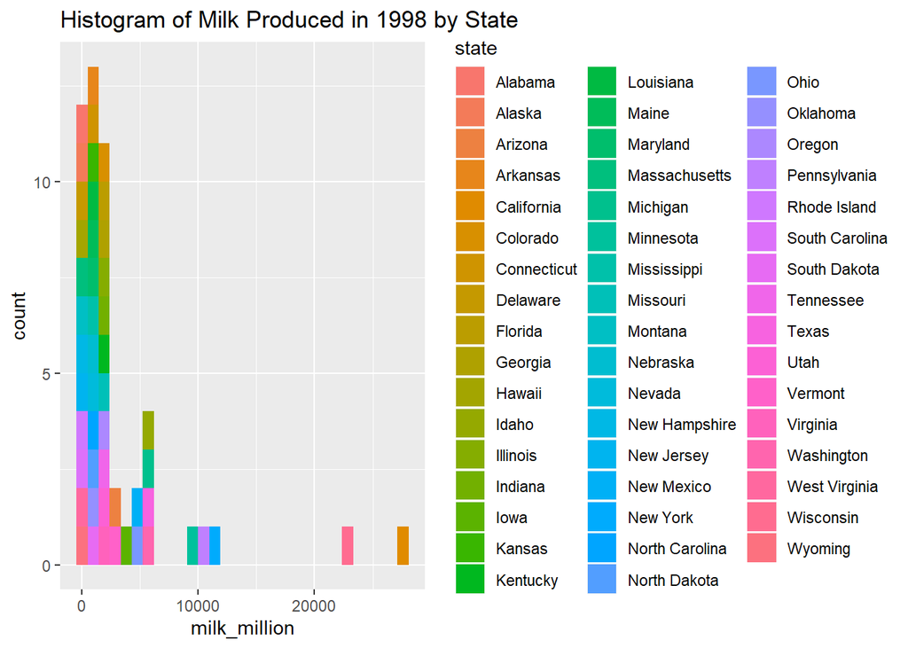

Summary of milk produced by state in 1998:

```
## # A tibble: 50 x 2
##    state       milk_million
##    <fct>              <dbl>
##  1 Alabama              386
##  2 Alaska                14
##  3 Arizona             2680
##  4 Arkansas             540
##  5 California         27620
##  6 Colorado            1689
##  7 Connecticut          529
##  8 Delaware             159
##  9 Florida             2337
## 10 Georgia             1437
## # ... with 40 more rows
```

The average milk produced in my birth year is 3145.22 million pounds.

The median milk produced in my birth year is 1411.5 million pounds.

The state that produced most milk in my birth year is California.

The state that produced least milk in my birth year is Alaska.

### Eugene Miller 1999

Plot of milk produced for year 1999:

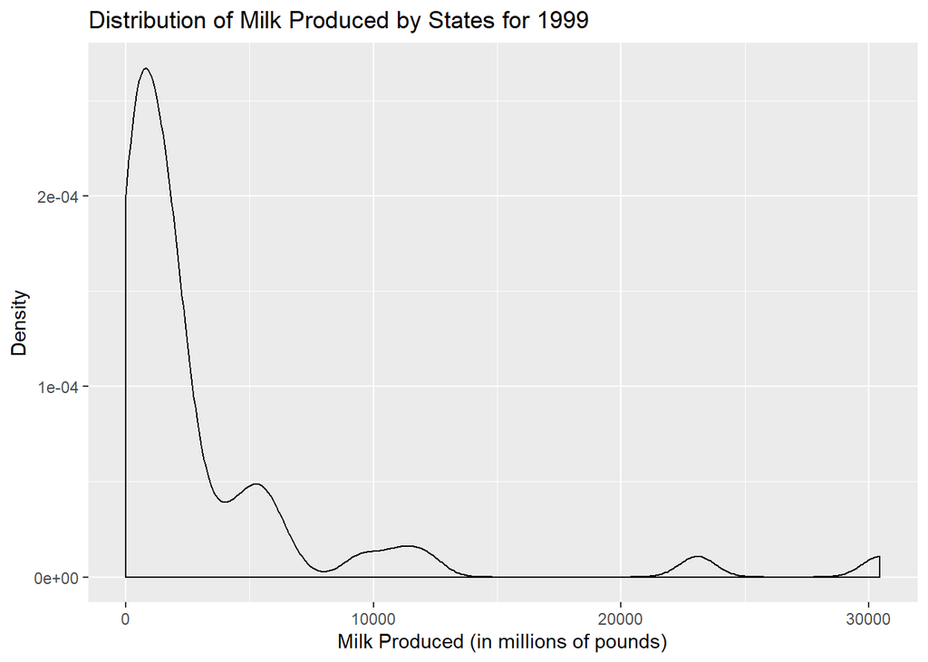

Summary of milk produced by state in 1999:

```
## # A tibble: 50 x 2
##    state       milk_million
##    <fct>              <dbl>
##  1 Alabama              376
##  2 Alaska                14
##  3 Arizona             2931
##  4 Arkansas             520
##  5 California         30444
##  6 Colorado            1728
##  7 Connecticut          520
##  8 Delaware             145
##  9 Florida             2398
## 10 Georgia             1449
## # ... with 40 more rows
```

Average state milk production in 1999 = 3251.8 million lb.

Median state milk production in 1999 = 1418 million lb.

Smallest producer of milk in 1999 = Alaska who produced 14 million lb.

### Johnny Tamanaha 1999

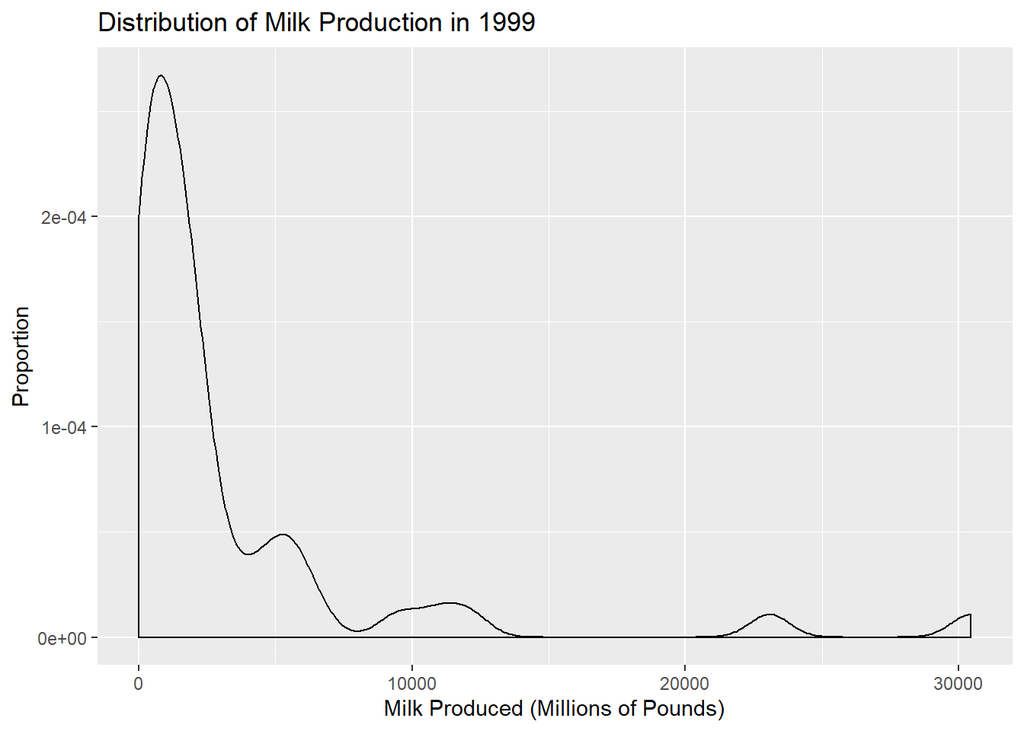

```r
milk_1999 <- milk %>%
  filter(year=='1999')
ggplot(milk_1999) +
  geom_density(mapping=aes(milk_million)) +
  labs(title="Distribution of Milk Production in 1999") +
  xlab("Milk Produced (Millions of Pounds)") +
  ylab("Proportion")
```

```r
mean <- milk_1999 %>%
  summarize(Mean=mean(milk_million))

median <- milk_1999 %>%
  summarize(Median=median(milk_million))

most_milk <- milk_1999 %>%
  filter(rank(desc(milk_million))<2)

least_milk <- milk_1999 %>%
  filter(rank(milk_million)<2)

mean
```

```
##     Mean
## 1 3251.8
```

Mean Milk Production in 1999: 3251.8 million pounds

```r
median
```

```
##   Median
## 1   1418
```

Median Milk Production in 1999: 1418 million pounds

```r
most_milk
```

```
##    region      state year milk_produced milk_million
## 1 Pacific California 1999    3.0444e+10        30444
```

Most Milk Production in 1999: California

```r
least_milk
```

```
##    region  state year milk_produced milk_million
## 1 Pacific Alaska 1999       1.4e+07           14
```

Least Milk Production in 1999: Alaska.

### Reflection on What We Found to be Most Helpful:

We found bivariate distributions with a time variable to be the most helpful in visualising this data, as it allowed us to look at how milk production has changed over time state by state. Using specific filters and dyplyr functions we were able to manipulate the data into easily readable formats then were then plotted using ggplot to produce an informative visualization.

### Reflection on Ethics of This Data Analysis:

This data analysis could hurt milk manufacturers in lesser producing states such as Alaska, or Connecticut because it may divert potential investors towards greater producing states such as Wisconsin and California. In addition, producers of milk alternatives may be happy about this analysis as it shows that in recent years milk production has begun to plateau in California, one of the largest producing states. This could indicate a decreased consumer demand for milk and therefore a movement towards milk alternatives.

# Lab 5 TEAM: ALL STARS

Johnny Tamanaha, Emily Archambault, Eugene Miller, Kaiyuan Fan, Jingzhi Zhang

9/29/2019

In 2017, the 5 states that produced the most milk:

[output not shown]